# Data Cleaning & Exploratory Data Analysis

# TASK 2: Cleaning — Step by Step

**Cleaning principles:**

1. Work on a **copy** of the raw data
2. Fix **one problem at a time**
3. **Log** every change
4. **Flag** invalid tests instead of deleting them

### Step 1: Setup & Change Log

`df = raw.copy()` preserves the original raw data. `note()` function records changes.

```python
df = raw.copy()
log = []
def note(step, n):
    log.append({"step": step, "rows_affected": int(n)})
    print(f"✔ {step}: {n} rows affected")
```

### Step 2: Standardise Column Names

Rename to **snake_case** for readability.

```python
df.columns = ["sample_id", "borehole", "depth_m", "rock_type", "weathering",
              "moisture", "diameter_mm", "ld_ratio", "dry_density", "porosity",
              "water_content", "vp_kms", "schmidt_r", "is50", "bts",
              "ucs", "ucs_unit", "failure_mode", "test_date", "lab", "valid_test"]
df.columns.tolist()
```

```
['sample_id',
 'borehole',
 'depth_m',
 'rock_type',
 'weathering',
 'moisture',
 'diameter_mm',
 'ld_ratio',
 'dry_density',
 'porosity',
 'water_content',
 'vp_kms',
 'schmidt_r',
 'is50',
 'bts',
 'ucs',
 'ucs_unit',
 'failure_mode',
 'test_date',
 'lab',
 'valid_test']
```

### Step 3: Placeholders → NaN

Replace all placeholder tokens before numeric conversion.

```python
before = df.isna().sum().sum()
df = df.replace(PLACEHOLDERS, np.nan)
df = df.replace(-777, np.nan)

# Object columns mein har cell ko safely string banao, phir strip karo
obj = [c for c in df.columns if not pd.api.types.is_numeric_dtype(df[c])]
for c in obj:
    df[c] = df[c].apply(lambda x: x.strip() if isinstance(x, str) else x)

df = df.replace("", np.nan)
note("Placeholders -> NaN (cells)", df.isna().sum().sum() - before)
```

```
✔ Placeholders -> NaN (cells): 51 rows affected
```

### Step 4: Remove Conflicting Duplicates

Same Sample ID with different UCS → **keep first**, drop rest.

```python
n0 = len(df)
df = df.drop_duplicates(subset=["sample_id"], keep="first")
note("Conflicting duplicates removed (kept first)", n0 - len(df))
```

```
✔ Conflicting duplicates removed (kept first): 20 rows affected
```

### Step 5: Clean Units from Text

Strip " mm" and " kg/m3" suffixes, then convert to numeric.

```python
n_diam = df["diameter_mm"].astype(str).str.contains("mm", na=False).sum()
df["diameter_mm"] = df["diameter_mm"].astype(str).str.replace("mm","",regex=False).str.strip()

n_dens = df["dry_density"].astype(str).str.contains("kg/m3", na=False).sum()
df["dry_density"] = df["dry_density"].astype(str).str.replace("kg/m3","",regex=False).str.strip()

num = ["depth_m","diameter_mm","ld_ratio","dry_density","porosity",
       "water_content","vp_kms","schmidt_r","is50","bts","ucs"]
df[num] = df[num].apply(pd.to_numeric, errors="coerce")
note("Diameter ' mm' suffix cleaned", n_diam)
note("Density ' kg/m3' suffix cleaned", n_dens)
```

```
✔ Diameter ' mm' suffix cleaned: 21 rows affected
✔ Density ' kg/m3' suffix cleaned: 21 rows affected
```

### Step 6: Standardise Rock Type

6 rock types, 20+ spellings. Map all to standard names with a defensive assert.

```python
def clean_rock(x):
    if pd.isna(x): return np.nan
    k = x.lower().replace("-","").replace(" ","").replace(".","")
    mapping = {
        "sandstone":"Sandstone", "ss":"Sandstone", "sandst":"Sandstone",
        "sandstn":"Sandstone",
        "limestone":"Limestone", "limestone":"Limestone", "ls":"Limestone",
        "limest":"Limestone",
        "shale":"Shale", "shl":"Shale", "sh":"Shale",
        "granite":"Granite", "gran":"Granite", "grnt":"Granite", "granit":"Granite",
        "mudstone":"Mudstone", "mdstone":"Mudstone", "mudst":"Mudstone",
        "basalt":"Basalt", "bslt":"Basalt", "bas":"Basalt", "baslt":"Basalt",
    }
    return mapping.get(k, "UNMAPPED:" + x)

old = df["rock_type"].copy()
df["rock_type"] = df["rock_type"].map(clean_rock)
note("Rock type labels corrected", (old != df["rock_type"]).sum())
assert not df["rock_type"].str.startswith("UNMAPPED").any()
df["rock_type"].value_counts()
```

```
✔ Rock type labels corrected: 105 rows affected
```

```
rock_type
Limestone    112
Sandstone    110
Mudstone     110
Shale        109
Granite      106
Basalt       103
Name: count, dtype: int64
```

### Step 7: Standardise Weathering Grade

```python
W_MAP = {
    "FRESH":"Fresh","F":"Fresh","GRADE-1":"Fresh","W1":"Fresh","FR":"Fresh",
    "SLIGHTLY WEATHERED":"Slightly Weathered","SW":"Slightly Weathered",
    "GRADE-2":"Slightly Weathered","W2":"Slightly Weathered",
    "SLGT-WTHRD":"Slightly Weathered",
    "MODERATELY WEATHERED":"Moderately Weathered","MW":"Moderately Weathered",
    "GRADE-3":"Moderately Weathered","W3":"Moderately Weathered",
    "HIGHLY WEATHERED":"Highly Weathered","HW":"Highly Weathered",
    "GRADE-4":"Highly Weathered","W4":"Highly Weathered",
    "COMPLETELY WEATHERED":"Completely Weathered","CW":"Completely Weathered",
    "GRADE-5":"Completely Weathered","W5":"Completely Weathered",
}
old = df["weathering"].copy()
df["weathering"] = df["weathering"].astype(str).str.upper().map(W_MAP)
note("Weathering codes standardised", (old != df["weathering"]).sum())

df["weathering"] = pd.Categorical(
    df["weathering"],
    categories=["Fresh","Slightly Weathered","Moderately Weathered",
                "Highly Weathered","Completely Weathered"],
    ordered=True)
df["weathering"].value_counts().sort_index()
```

```
✔ Weathering codes standardised: 258 rows affected
```

```
weathering
Fresh                   187
Slightly Weathered      168
Moderately Weathered    153
Highly Weathered         88
Completely Weathered     54
Name: count, dtype: int64
```

### Step 8: Convert UCS to MPa

```python
print("BEFORE conversion:")
print(df.groupby("ucs_unit")["ucs"].describe()[["count","min","50%","max"]])

to_mpa = {"MPa": 1.0, "Pa": 1e-6, "ksi": 6.89476, "kgf/cm2": 0.0980665}
n_conv = (df["ucs_unit"] != "MPa").sum()
df["ucs"] = df["ucs"] * df["ucs_unit"].map(to_mpa)
df["ucs_unit"] = "MPa"
note("UCS converted to MPa", n_conv)
print("\nAFTER conversion:")
print(df["ucs"].describe().round(2))
```

```
BEFORE conversion:
          count           min           50%           max
ucs_unit
MPa       494.0 -1.520000e+01  2.800000e+01  9.271000e+02
Pa         74.0  1.150000e+06  3.367500e+07  1.764800e+08
kgf/cm2    39.0  2.549300e+01  4.268548e+02  1.814184e+03
ksi        43.0  4.075568e-01  4.426560e+00  5.822000e+01
✔ UCS converted to MPa: 156 rows affected

AFTER conversion:
count    650.00
mean      43.74
std       62.22
min      -15.20
25%       12.31
50%       28.79
75%       56.04
max      927.10
Name: ucs, dtype: float64
```

### Step 9: Density Unit Conversion

Values > 100 must be lb/ft³ → divide by 62.42796.

```python
mask_lb = df["dry_density"] > 100
df.loc[mask_lb, "dry_density"] = (df.loc[mask_lb, "dry_density"] / 62.42796).round(3)
note("Density converted lb/ft3 -> g/cm3", mask_lb.sum())
print(df["dry_density"].describe().round(3))
```

```
✔ Density converted lb/ft3 -> g/cm3: 42 rows affected
count    629.000
mean       3.679
std        8.575
min        1.402
25%        1.812
50%        2.214
75%        2.574
max       93.400
Name: dry_density, dtype: float64
```

### Step 10: Physically Impossible Values

A value that breaks physics is an error, not an outlier. Set to NaN.

```python
rules = {
    "depth_m":       (0, 200),
    "porosity":      (0, 60),
    "dry_density":   (1.2, 3.3),
    "ucs":           (0.1, 400),
    "schmidt_r":     (10, 70),
    "vp_kms":        (0.5, 7.5),
    "ld_ratio":      (1.0, 3.5),
    "diameter_mm":   (30, 150),
    "water_content": (0, 50),
}
for col, (lo, hi) in rules.items():
    bad = df[col].notna() & ~df[col].between(lo, hi)
    if bad.any():
        print(f"{col}: {bad.sum()} impossible values -> {df.loc[bad, col].round(1).tolist()[:6]}")
    df.loc[bad, col] = np.nan
    note(f"Out-of-range {col} set to NaN", bad.sum())
```

```
depth_m: 3 impossible values -> [-0.9, -12.3, -4.5]
✔ Out-of-range depth_m set to NaN: 3 rows affected
porosity: 3 impossible values -> [245.0, 132.0, 178.0]
✔ Out-of-range porosity set to NaN: 3 rows affected
dry_density: 24 impossible values -> [32.0, 89.3, 93.4, 38.8, 36.8, 42.5]
✔ Out-of-range dry_density set to NaN: 24 rows affected
ucs: 6 impossible values -> [-15.2, 927.1, 401.4, -3.6, -8.4, 866.3]
✔ Out-of-range ucs set to NaN: 6 rows affected
schmidt_r: 2 impossible values -> [150.0, 220.0]
✔ Out-of-range schmidt_r set to NaN: 2 rows affected
vp_kms: 1 impossible values -> [-3.1]
✔ Out-of-range vp_kms set to NaN: 1 rows affected
ld_ratio: 2 impossible values -> [5.6, 0.4]
✔ Out-of-range ld_ratio set to NaN: 2 rows affected
✔ Out-of-range diameter_mm set to NaN: 0 rows affected
water_content: 2 impossible values -> [68.0, -2.5]
✔ Out-of-range water_content set to NaN: 2 rows affected
```

### Step 11: Flag Invalid Tests

Two types: L/D > 3.0 and failure outside specimen body. **Flag, don't delete.**

```python
df["valid_test"] = True

mask_ld = df["ld_ratio"] > 3.0
df.loc[mask_ld, "valid_test"] = False
note("Flagged invalid: L/D > 3.0", mask_ld.sum())

mask_fail = df["failure_mode"].eq("Failed outside specimen body")
df.loc[mask_fail, "valid_test"] = False
note("Flagged invalid: failed outside specimen body", mask_fail.sum())

print(df.groupby("valid_test")["ucs"].median().round(2))
```

```
✔ Flagged invalid: L/D > 3.0: 0 rows affected
✔ Flagged invalid: failed outside specimen body: 130 rows affected
valid_test
False    30.69
True     28.18
Name: ucs, dtype: float64
```

### Step 12: Parse Dates Explicitly

Avoid `format="mixed"` — try each known format explicitly.

```python
shortcut = pd.to_datetime(df["test_date"], format="mixed", dayfirst=True, errors="coerce")

formats = ["%b-%d-%Y", "%d.%m.%Y", "%Y_%m_%d", "%d/%m/%Y %H:%M", "%Y-%m-%d"]
parsed = pd.Series(pd.NaT, index=df.index, dtype="datetime64[ns]")
for f in formats:
    parsed = parsed.fillna(pd.to_datetime(df["test_date"], format=f, errors="coerce"))

print("Dates the shortcut got WRONG:", (shortcut != parsed).sum())
df["test_date"] = parsed
note("Unparseable dates", df["test_date"].isna().sum())
df["test_date"].agg(["min","max"])
```

```
Dates the shortcut got WRONG: 186
✔ Unparseable dates: 0 rows affected
```

```
min   2024-01-01
max   2024-12-27
Name: test_date, dtype: datetime64[ns]
```

### Step 13: Outlier Detection

```python
def iqr_flag(s, k=1.5):
    q1, q3 = s.quantile([.25, .75]); iqr = q3 - q1
    return ~s.between(q1 - k*iqr, q3 + k*iqr)

df["ucs_outlier_iqr"] = df.groupby("rock_type")["ucs"].transform(iqr_flag) & df["ucs"].notna()
df["ucs_schmidt_ratio"] = df["ucs"] / df["schmidt_r"]
df["ucs_suspect"] = df["ucs_schmidt_ratio"].notna() & (df["ucs_schmidt_ratio"] > 8)
note("Suspicious UCS/Schmidt-R ratio flagged", df["ucs_suspect"].sum())
print(df.loc[df["ucs_suspect"],
             ["sample_id","rock_type","weathering","ucs","schmidt_r","ucs_schmidt_ratio"]]
        .sort_values("ucs_schmidt_ratio", ascending=False).round(2).head(8))
```

```
✔ Suspicious UCS/Schmidt-R ratio flagged: 0 rows affected
Empty DataFrame
Columns: [sample_id, rock_type, weathering, ucs, schmidt_r, ucs_schmidt_ratio]
Index: []
```

### Step 14: Handle Missing Values

Target missing → drop. Predictors → group median (rock type + weathering).

```python
n0 = len(df)
df = df.dropna(subset=["ucs"])
note("Rows dropped: missing UCS (target)", n0 - len(df))

impute_cols = ["depth_m","dry_density","porosity","water_content",
               "vp_kms","schmidt_r","is50","bts"]
for c in impute_cols:
    df[f"{c}_was_missing"] = df[c].isna()
    grp_med = df.groupby(["rock_type","weathering"], observed=True)[c].transform("median")
    df[c] = df[c].fillna(grp_med).fillna(df.groupby("rock_type")[c].transform("median"))
    note(f"Imputed {c}", df[f"{c}_was_missing"].sum())

df["moisture"] = df["moisture"].fillna("Unknown")
df["failure_mode"] = df["failure_mode"].fillna("Not recorded")
```

```
✔ Rows dropped: missing UCS (target): 6 rows affected
✔ Imputed depth_m: 3 rows affected
✔ Imputed dry_density: 45 rows affected
✔ Imputed porosity: 36 rows affected
✔ Imputed water_content: 92 rows affected
✔ Imputed vp_kms: 84 rows affected
✔ Imputed schmidt_r: 40 rows affected
✔ Imputed is50: 70 rows affected
✔ Imputed bts: 79 rows affected
```

### Step 15: Save Clean Dataset + Log

Save `ucs_clean.csv` and the change-log DataFrame.

```python
clean = df[df["valid_test"] & ~df["ucs_suspect"]].copy()
clean["ucs_schmidt_ratio"] = clean["ucs"] / clean["schmidt_r"]

print(f"Raw rows: {len(raw)}  ->  after cleaning: {len(df)}  ->  valid for analysis: {len(clean)}")

clean.to_excel("ucs_clean.xlsx", index=False)
clean.to_csv("ucs_clean.csv", index=False)

log_df = pd.DataFrame(log)
log_df
```

```
Raw rows: 670  ->  after cleaning: 644  ->  valid for analysis: 517
```

|  | step | rows_affected |
| --- | --- | --- |
| 0 | Placeholders -> NaN (cells) | 51 |
| 1 | Conflicting duplicates removed (kept first) | 20 |
| 2 | Diameter ' mm' suffix cleaned | 21 |
| 3 | Density ' kg/m3' suffix cleaned | 21 |
| 4 | Rock type labels corrected | 105 |
| 5 | Weathering codes standardised | 258 |
| 6 | UCS converted to MPa | 156 |
| 7 | Density converted lb/ft3 -> g/cm3 | 42 |
| 8 | Out-of-range depth_m set to NaN | 3 |
| 9 | Out-of-range porosity set to NaN | 3 |
| 10 | Out-of-range dry_density set to NaN | 24 |
| 11 | Out-of-range ucs set to NaN | 6 |
| 12 | Out-of-range schmidt_r set to NaN | 2 |
| 13 | Out-of-range vp_kms set to NaN | 1 |
| 14 | Out-of-range ld_ratio set to NaN | 2 |
| 15 | Out-of-range diameter_mm set to NaN | 0 |
| 16 | Out-of-range water_content set to NaN | 2 |
| 17 | Flagged invalid: L/D > 3.0 | 0 |
| 18 | Flagged invalid: failed outside specimen body | 130 |
| 19 | Unparseable dates | 0 |
| 20 | Suspicious UCS/Schmidt-R ratio flagged | 0 |
| 21 | Rows dropped: missing UCS (target) | 6 |
| 22 | Imputed depth_m | 3 |
| 23 | Imputed dry_density | 45 |
| 24 | Imputed porosity | 36 |
| 25 | Imputed water_content | 92 |
| 26 | Imputed vp_kms | 84 |
| 27 | Imputed schmidt_r | 40 |
| 28 | Imputed is50 | 70 |
| 29 | Imputed bts | 79 |

# TASK 3: Exploratory Data Analysis

Now that the data is clean, we explore:

### EDA 2: Rock Type & Weathering Distribution

Pie charts show categorical proportions clearly.

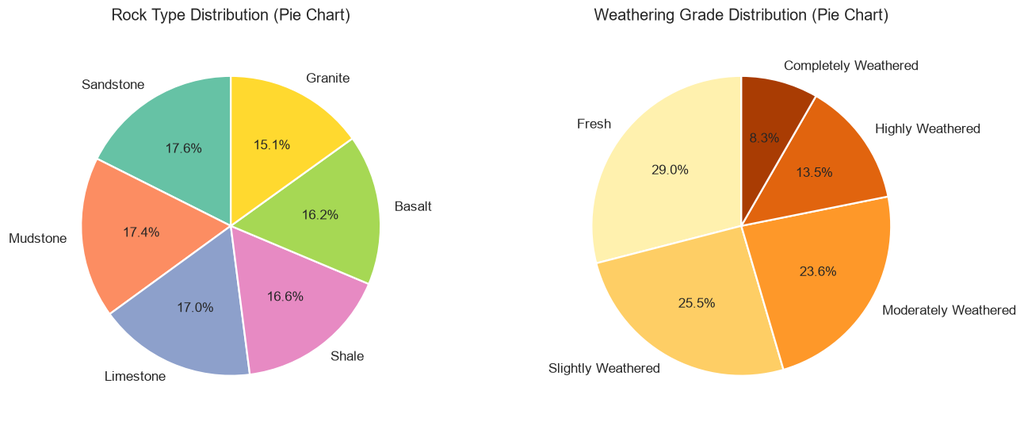

```python
fig, ax = plt.subplots(1, 2, figsize=(13, 5))

clean["rock_type"].value_counts().plot.pie(
    autopct="%1.1f%%", startangle=90, ax=ax[0],
    colors=sns.color_palette("Set2", n_colors=6),
    wedgeprops={"edgecolor":"white","linewidth":1.5},
    textprops={"fontsize":11}, ylabel="")
ax[0].set_title("Rock Type Distribution (Pie Chart)", fontsize=13, pad=15)

clean["weathering"].value_counts().sort_index().plot.pie(
    autopct="%1.1f%%", startangle=90, ax=ax[1],
    colors=sns.color_palette("YlOrBr", n_colors=5),
    wedgeprops={"edgecolor":"white","linewidth":1.5},
    textprops={"fontsize":11}, ylabel="")
ax[1].set_title("Weathering Grade Distribution (Pie Chart)", fontsize=13, pad=15)

plt.tight_layout()
plt.savefig("fig2_pie_rock_weathering.png", dpi=130, bbox_inches="tight")
plt.show()
```

### EDA 3: Moisture & Borehole Distribution

Pie charts for moisture conditions and samples per borehole.

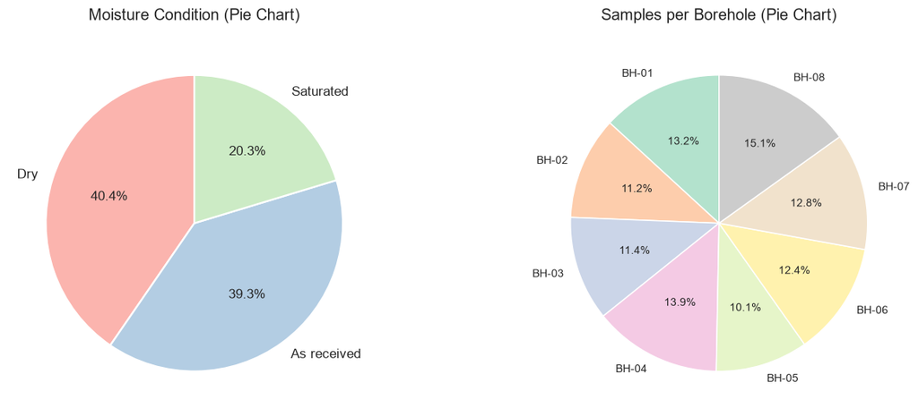

```python
fig, ax = plt.subplots(1, 2, figsize=(13, 5))

clean["moisture"].value_counts().plot.pie(
    autopct="%1.1f%%", startangle=90, ax=ax[0],
    colors=sns.color_palette("Pastel1", n_colors=3),
    wedgeprops={"edgecolor":"white","linewidth":1.5},
    textprops={"fontsize":11}, ylabel="")
ax[0].set_title("Moisture Condition (Pie Chart)", fontsize=13, pad=15)

clean["borehole"].value_counts().sort_index().plot.pie(
    autopct="%1.1f%%", startangle=90, ax=ax[1],
    colors=sns.color_palette("Pastel2", n_colors=8),
    wedgeprops={"edgecolor":"white","linewidth":1.0},
    textprops={"fontsize":9}, ylabel="")
ax[1].set_title("Samples per Borehole (Pie Chart)", fontsize=13, pad=15)

plt.tight_layout()
plt.savefig("fig3_pie_moisture_borehole.png", dpi=130, bbox_inches="tight")
plt.show()
```

### EDA 4: UCS Distribution

Raw UCS is skewed; log10(UCS) is nearly normal.

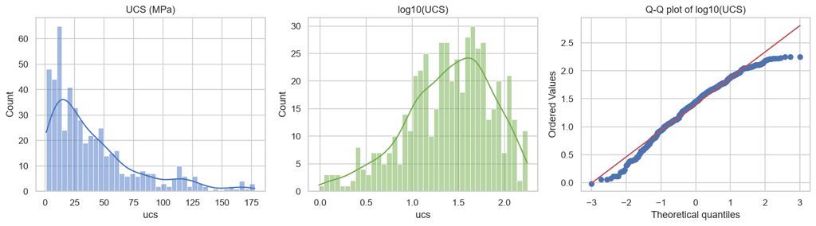

```
Skewness raw: 1.47   |   log10: -0.55
```

```python
fig, ax = plt.subplots(1, 3, figsize=(14, 4))
sns.histplot(clean["ucs"], bins=40, kde=True, ax=ax[0], color="#4472c4")
ax[0].set_title("UCS (MPa)")
sns.histplot(np.log10(clean["ucs"]), bins=40, kde=True, ax=ax[1], color="#70ad47")
ax[1].set_title("log10(UCS)")
stats.probplot(np.log10(clean["ucs"]), plot=ax[2]); ax[2].set_title("Q-Q plot of log10(UCS)")
plt.tight_layout(); plt.savefig("fig4_ucs_dist.png", dpi=130, bbox_inches="tight"); plt.show()

print(f"Skewness raw: {clean['ucs'].skew():.2f}   |   log10: {np.log10(clean['ucs']).skew():.2f}")
```

### EDA 5: UCS by Rock Type

Boxplot + strip plot, log y-axis, ordered by median UCS.

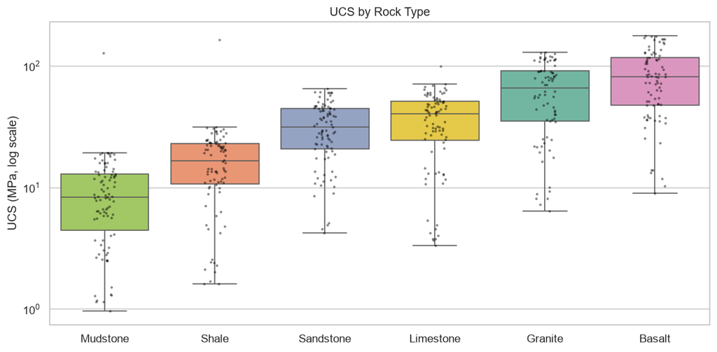

| rock_type | count | mean | 50% | min | max |
| --- | --- | --- | --- | --- | --- |
| Mudstone | 90.0 | 10.4 | 8.4 | 1.0 | 128.9 |
| Shale | 86.0 | 18.1 | 16.6 | 1.6 | 164.6 |
| Sandstone | 91.0 | 32.6 | 31.7 | 4.3 | 65.0 |
| Limestone | 88.0 | 37.3 | 40.5 | 3.3 | 100.4 |
| Granite | 78.0 | 65.7 | 65.9 | 6.4 | 129.4 |
| Basalt | 84.0 | 84.7 | 81.4 | 9.0 | 177.9 |

```python
order = clean.groupby("rock_type")["ucs"].median().sort_values().index
plt.figure(figsize=(10, 5))
sns.boxplot(data=clean, x="rock_type", y="ucs", order=order,
            hue="rock_type", palette="Set2", legend=False, showfliers=False)
sns.stripplot(data=clean, x="rock_type", y="ucs", order=order,
              size=2.5, alpha=.45, color="black")
plt.yscale("log"); plt.ylabel("UCS (MPa, log scale)"); plt.xlabel("")
plt.title("UCS by Rock Type"); plt.tight_layout()
plt.savefig("fig5_box_ucs_rock.png", dpi=130, bbox_inches="tight"); plt.show()
clean.groupby("rock_type")["ucs"].describe()[["count","mean","50%","min","max"]].loc[order].round(1)
```

### EDA 6: Effect of Weathering Grade

Faceted boxplots — one per rock type. Grade V approaches soil strength.

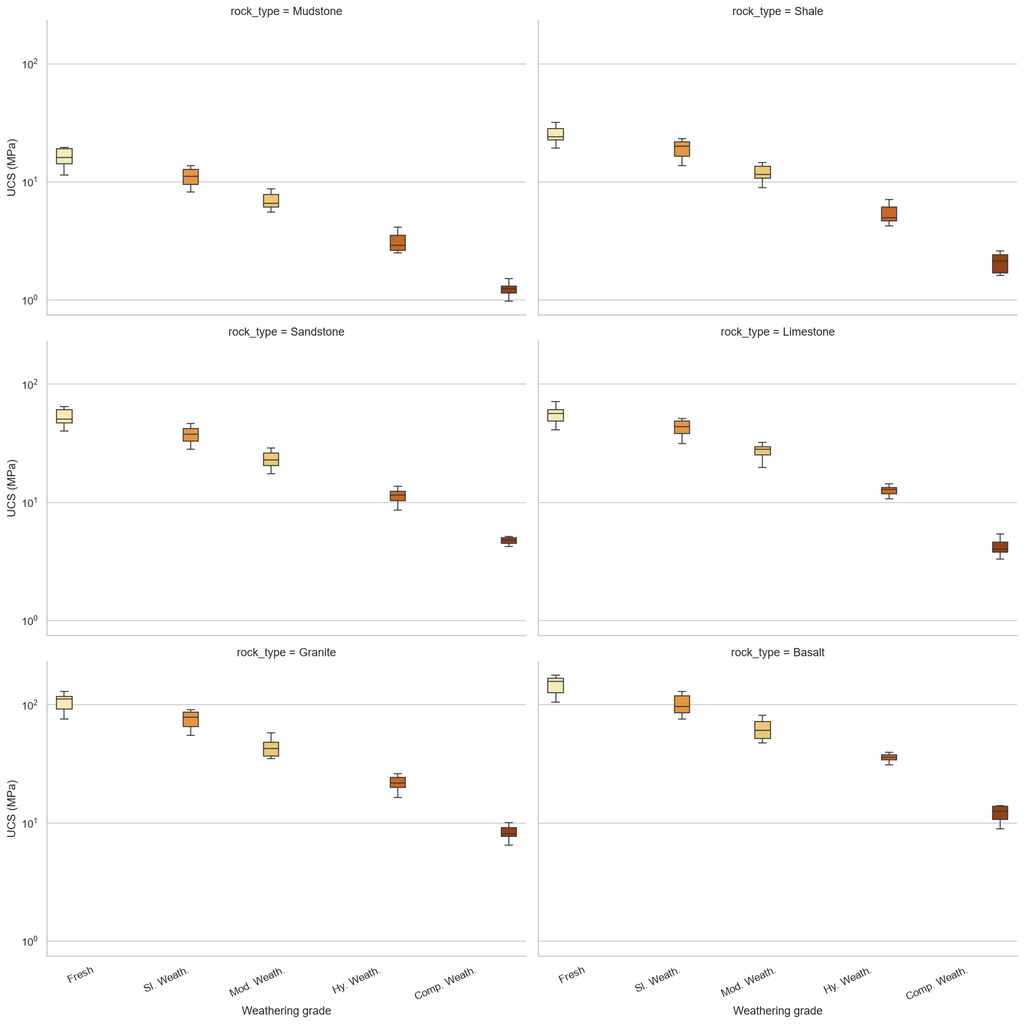

```
=== UCS as % of Fresh strength (per rock type) ===
weathering  Fresh  Slightly Weathered  Moderately Weathered  Highly Weathered  Completely Weathered
rock_type
Mudstone    100.0                70.0                  41.0              18.0                   8.0
Shale       100.0                83.0                  48.0              20.0                   9.0
Sandstone   100.0                75.0                  45.0              23.0                   9.0
Limestone   100.0                78.0                  50.0              23.0                   7.0
Granite     100.0                70.0                  38.0              19.0                   7.0
Basalt      100.0                61.0                  39.0              23.0                   8.0
```

```python
g = sns.catplot(data=clean, x="weathering", y="ucs", col="rock_type",
                col_order=order, kind="box", col_wrap=2,
                height=5, aspect=1.5,
                hue="weathering", palette="YlOrBr", legend=False,
                showfliers=False)

g.set(yscale="log")
g.set_axis_labels("Weathering grade", "UCS (MPa)")

# X-axis labels — chhote naam, rotate
short_labels = ["Fresh", "Sl. Weath.", "Mod. Weath.", "Hy. Weath.", "Comp. Weath."]
for ax in g.axes.flat:
    ax.set_xticks(range(5))
    ax.set_xticklabels(short_labels, rotation=25, ha="right", fontsize=11)
    ax.tick_params(axis='y', labelsize=11)

plt.tight_layout()
plt.savefig("fig6_weathering_effect.png", dpi=130, bbox_inches="tight")
plt.show()

# Table alag se print
red = clean.groupby(["rock_type","weathering"], observed=True)["ucs"].median().unstack()
result = (red.div(red["Fresh"], axis=0) * 100).round(0).loc[order]
print("=== UCS as % of Fresh strength (per rock type) ===")
print(result)
```

### EDA 7: Spearman Correlation Matrix

Spearman (not Pearson) because UCS is skewed and relationships are non-linear.

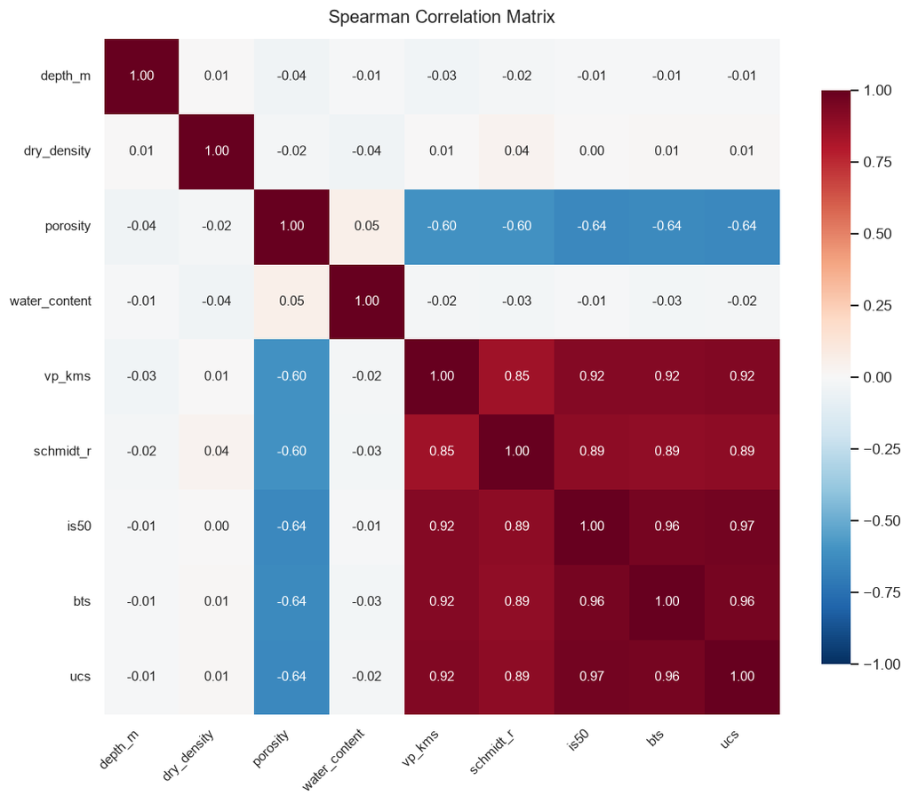

```
is50             0.97
bts              0.96
vp_kms           0.92
schmidt_r        0.89
porosity        -0.64
water_content   -0.02
dry_density      0.01
depth_m         -0.01
Name: ucs, dtype: float64
```

```python
cols = ["depth_m","dry_density","porosity","water_content","vp_kms",
        "schmidt_r","is50","bts","ucs"]
corr = clean[cols].corr(method="spearman")

plt.figure(figsize=(10, 8.5))
sns.heatmap(corr, annot=True, fmt=".2f", cmap="RdBu_r",
            vmin=-1, vmax=1, square=True,
            annot_kws={"size": 10}, cbar_kws={"shrink": 0.8})
plt.title("Spearman Correlation Matrix", fontsize=13, pad=12)
plt.xticks(rotation=45, ha="right", fontsize=10)
plt.yticks(fontsize=10)
plt.tight_layout()
plt.savefig("fig7_corr_heatmap.png", dpi=130, bbox_inches="tight")
plt.show()

print(corr["ucs"].drop("ucs").sort_values(key=abs, ascending=False).round(2))
```

### EDA 8: Index Tests vs UCS

Is(50) shows tightest correlation (ρ ≈ 0.97).

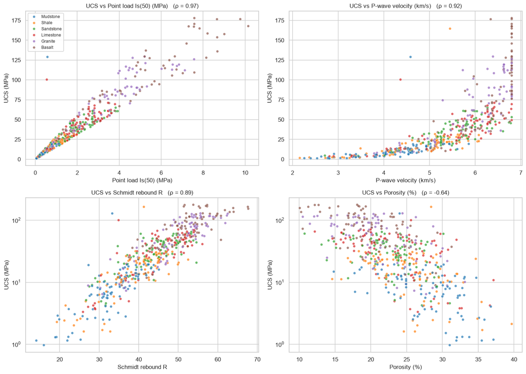

```python
fig, ax = plt.subplots(2, 2, figsize=(14, 10))
pal = dict(zip(order, sns.color_palette("tab10", len(order))))
pairs = [("is50","Point load Is(50) (MPa)"),
         ("vp_kms","P-wave velocity (km/s)"),
         ("schmidt_r","Schmidt rebound R"),
         ("porosity","Porosity (%)")]

for a, (x, lab) in zip(ax.flat, pairs):
    sns.scatterplot(data=clean, x=x, y="ucs", hue="rock_type",
                    hue_order=order, palette=pal,
                    s=22, alpha=.7, ax=a, legend=(x=="is50"))
    a.set_xlabel(lab, fontsize=11)
    a.set_ylabel("UCS (MPa)", fontsize=11)
    rho = stats.spearmanr(clean[x], clean["ucs"]).statistic
    a.set_title(f"UCS vs {lab}   (ρ = {rho:.2f})", fontsize=11)

ax[1,0].set_yscale("log")
ax[1,1].set_yscale("log")

if ax[0,0].get_legend():
    ax[0,0].legend(fontsize=8, loc="upper left", framealpha=0.9)

plt.tight_layout()
plt.savefig("fig8_scatter_index.png", dpi=130, bbox_inches="tight")
plt.show()
```

```python
rows = []
for rt, g in clean[~clean["is50_was_missing"]].groupby("rock_type"):
    k = (g["ucs"] * g["is50"]).sum() / (g["is50"] ** 2).sum()
    pred = k * g["is50"]
    r2 = 1 - ((g["ucs"] - pred) ** 2).sum() / ((g["ucs"] - g["ucs"].mean()) ** 2).sum()
    rows.append({"rock_type": rt, "n": len(g),
                 "k (UCS/Is50)": round(k, 1), "R2": round(r2, 2)})
kfit = pd.DataFrame(rows).set_index("rock_type").loc[order]
kfit
```

| rock_type | n | k (UCS/Is50) | R2 |
| --- | --- | --- | --- |
| Mudstone | 82 | 22.3 | 0.16 |
| Shale | 74 | 19.1 | 0.86 |
| Sandstone | 76 | 18.3 | 0.86 |
| Limestone | 77 | 19.3 | 0.62 |
| Granite | 71 | 20.0 | 0.87 |
| Basalt | 75 | 19.2 | 0.90 |

### EDA 9: UCS = k · Is(50) per Rock Type

Least squares through origin. Fitted k values fall in published range (10–30).

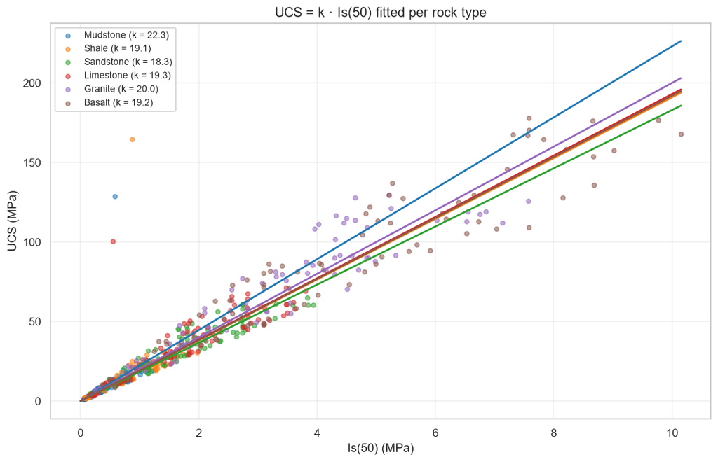

```python
x = np.linspace(0, clean["is50"].max(), 60)

plt.figure(figsize=(10, 6.5))
for rt in order:
    g = clean[clean["rock_type"] == rt]
    plt.scatter(g["is50"], g["ucs"], s=18, alpha=.55,
                color=pal[rt], label=f"{rt} (k = {kfit.loc[rt,'k (UCS/Is50)']})")
    plt.plot(x, kfit.loc[rt,"k (UCS/Is50)"] * x, color=pal[rt], lw=1.8)

plt.xlabel("Is(50) (MPa)", fontsize=12)
plt.ylabel("UCS (MPa)", fontsize=12)
plt.title("UCS = k · Is(50) fitted per rock type", fontsize=13)
plt.legend(fontsize=9, loc="upper left", framealpha=0.9)
plt.grid(alpha=0.3)
plt.tight_layout()
plt.savefig("fig9_kfit.png", dpi=130, bbox_inches="tight")
plt.show()
```

### EDA 10: Moisture Effect — Control for Confounding

Normalise each UCS by the median of its own rock type + weathering group.

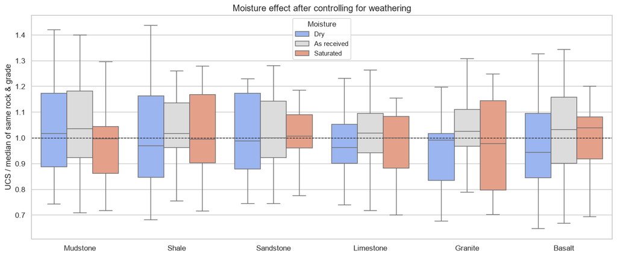

```python
clean["ucs_rel"] = clean["ucs"] / clean.groupby(
    ["rock_type","weathering"], observed=True)["ucs"].transform("median")

plt.figure(figsize=(13, 5.5))
sns.boxplot(data=clean[clean["moisture"] != "Unknown"],
            x="rock_type", y="ucs_rel",
            hue="moisture", order=order,
            hue_order=["Dry","As received","Saturated"],
            showfliers=False, palette="coolwarm")
plt.axhline(1, color="k", lw=.9, ls="--")
plt.ylabel("UCS / median of same rock & grade", fontsize=12)
plt.xlabel("")
plt.title("Moisture effect after controlling for weathering", fontsize=13)
plt.xticks(fontsize=11)
plt.yticks(fontsize=11)
plt.legend(title="Moisture", fontsize=10, title_fontsize=11)
plt.tight_layout()
plt.savefig("fig10_moisture.png", dpi=130, bbox_inches="tight")
plt.show()
```

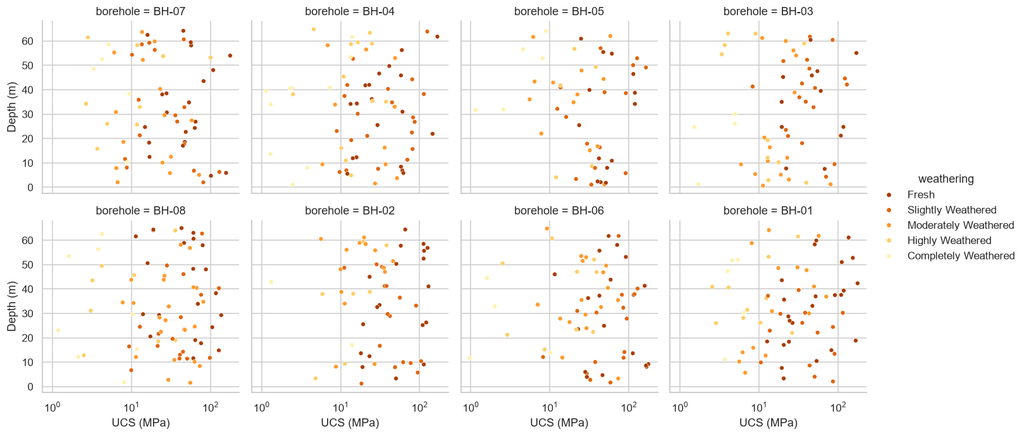

```python
g = sns.relplot(data=clean, x="ucs", y="depth_m", col="borehole",
                col_wrap=4, hue="weathering", palette="YlOrBr_r",
                height=3.2, aspect=1.0, s=20)

for a in g.axes.flat:
    a.invert_yaxis()
    a.set_xscale("log")

g.set_axis_labels("UCS (MPa)", "Depth (m)")
plt.savefig("fig11_depth_borehole.png", dpi=120, bbox_inches="tight")
plt.show()
```

### EDA 12: ISRM Strength Classification

`pd.cut` bins UCS into R0–R6 classes.

```python
bins   = [0, 1, 5, 25, 50, 100, 250, np.inf]
labels = ["R0 Extremely weak","R1 Very weak","R2 Weak",
          "R3 Medium strong","R4 Strong","R5 Very strong","R6 Extremely strong"]
clean["isrm_class"] = pd.cut(clean["ucs"], bins=bins, labels=labels)
pd.crosstab(clean["rock_type"], clean["isrm_class"]).loc[order]
```

| isrm_class rock_type | R0 Extremely weak | R1 Very weak | R2 Weak | R3 Medium strong | R4 Strong | R5 Very strong |
| --- | --- | --- | --- | --- | --- | --- |
| Mudstone | 1 | 22 | 66 | 0 | 0 | 1 |
| Shale | 0 | 13 | 61 | 11 | 0 | 1 |
| Sandstone | 0 | 3 | 28 | 47 | 13 | 0 |
| Limestone | 0 | 8 | 15 | 39 | 25 | 1 |
| Granite | 0 | 0 | 16 | 15 | 29 | 18 |
| Basalt | 0 | 0 | 7 | 18 | 29 | 30 |

### EDA 13: Did Cleaning Matter?

RAW UCS column vs CLEAN UCS — unit errors made statistics meaningless.

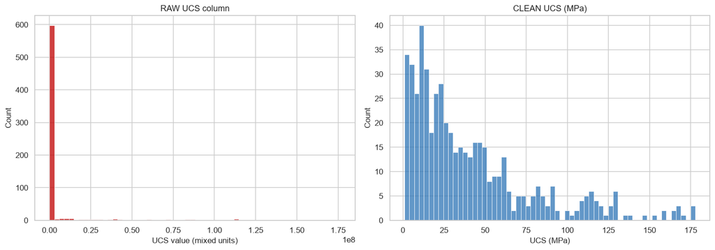

```
Raw mean:   5,097,151.9
Clean mean: 40.59 MPa
```

```python
raw_ucs = pd.to_numeric(raw["UCS"].replace(PLACEHOLDERS, np.nan), errors="coerce")

fig, ax = plt.subplots(1, 2, figsize=(14, 5))

sns.histplot(raw_ucs.dropna(), bins=60, ax=ax[0], color="#c00000")
ax[0].set_title("RAW UCS column", fontsize=12)
ax[0].set_xlabel("UCS value (mixed units)", fontsize=11)
ax[0].set_ylabel("Count", fontsize=11)

sns.histplot(clean["ucs"], bins=60, ax=ax[1], color="#2e75b6")
ax[1].set_title("CLEAN UCS (MPa)", fontsize=12)
ax[1].set_xlabel("UCS (MPa)", fontsize=11)
ax[1].set_ylabel("Count", fontsize=11)

plt.tight_layout()
plt.savefig("fig12_raw_vs_clean.png", dpi=130, bbox_inches="tight")
plt.show()

print(f"Raw mean:   {raw_ucs.mean():,.1f}")
print(f"Clean mean: {clean['ucs'].mean():.2f} MPa")
```

# REPORT: Findings & Discussion

## Summary

**Task 2 — Cleaning**  
Every change logged; invalid tests flagged, not deleted. Final dataset saved as `ucs_clean.csv`.

## Conclusion

A systematic data-cleaning workflow converted a deliberately corrupted dataset into an analysis-ready form. The cleaned dataset revealed physically sensible relationships between UCS, rock type, weathering, and index tests.

**Key lesson:** data cleaning is not optional — silent errors make any downstream analysis meaningless.

**Next step:** build a predictive model: `log(UCS)` from Is(50), Vp, Schmidt R, porosity, rock type, and weathering — cross-validated by borehole.

## References

### Standards & Test Methods

1. **ASTM D7012-14** — *Standard Test Methods for Compressive Strength and Elastic Moduli of Intact Rock Core Specimens under Varying States of Stress and Temperatures.* ASTM International, West Conshohocken, PA. https://www.astm.org/d7012-14e01.html
2. **ASTM D5731-16** — *Standard Test Method for Determination of the Point Load Strength Index of Rock and Application to Rock Strength Classifications.* ASTM International. https://www.astm.org/d5731-16.html
3. **ISRM (1981)** — *Rock Characterization, Testing and Monitoring: ISRM Suggested Methods.* E.T. Brown (ed.), Pergamon Press, Oxford.

### Books & Reference Texts

4. **Ulusay, R. & Hudson, J.A. (eds.) (2007)** — *The Complete ISRM Suggested Methods for Rock Characterization, Testing and Monitoring: 1974–2006.* ISRM, Ankara, Turkey.
5. **Hoek, E. & Brown, E.T. (1980)** — *Underground Excavations in Rock.* Institution of Mining and Metallurgy, London.
6. **Jaeger, J.C., Cook, N.G.W. & Zimmerman, R.W. (2007)** — *Fundamentals of Rock Mechanics* (4th ed.). Blackwell Publishing, Oxford.
7. **Goodman, R.E. (1989)** — *Introduction to Rock Mechanics* (2nd ed.). John Wiley & Sons, New York.
8. **Bieniawski, Z.T. (1989)** — *Engineering Rock Mass Classifications.* Wiley-Interscience, New York.

### Empirical Relationships (UCS ↔ Index Tests)

9. **Kahraman, S. (2001)** — Evaluation of the association between the Schmidt hammer value and the uniaxial compressive strength of rock. *International Journal of Rock Mechanics and Mining Sciences*, 38(2), 267–272. https://doi.org/10.1016/S1365-1609(00)00072-X
10. **Karakus, M. & Tutmez, B. (2006)** — Fuzzy and multiple regression modelling for evaluation of intact rock strength based on point load, Schmidt hammer and sonic velocity. *Rock Mechanics and Rock Engineering*, 39(1), 45–57. https://doi.org/10.1007/s00603-005-0050-y
11. **Yagiz, S. (2009)** — Predicting uniaxial compressive strength, modulus of elasticity and index properties of rocks using the Schmidt hammer. *Bulletin of Engineering Geology and the Environment*, 68(1), 55–63. https://doi.org/10.1007/s10064-008-0172-z
12. **Kurtulus, C., Sertcelik, F. & Sertcelik, I. (2012)** — Correlating P-wave velocity with uniaxial compressive strength of rocks. *Energy Education Science and Technology Part A*, 29(2), 1089–1096.
13. **Vasarhelyi, B. (2005)** — Statistical analysis of the influence of water content on the strength of the Miocene limestone. *Rock Mechanics and Rock Engineering*, 38(1), 69–76. https://doi.org/10.1007/s00603-004-0034-3

### Data Cleaning & Statistics

14. **Wickham, H. (2014)** — Tidy Data. *Journal of Statistical Software*, 59(10), 1–23. https://doi.org/10.18637/jss.v059.i10
15. **Tukey, J.W. (1977)** — *Exploratory Data Analysis.* Addison-Wesley, Reading, MA.
16. **Hastie, T., Tibshirani, R. & Friedman, J. (2009)** — *The Elements of Statistical Learning: Data Mining, Inference, and Prediction* (2nd ed.). Springer, New York. https://hastie.su.domains/ElemStatLearn/

### Software & Tools

17. **McKinney, W. (2010)** — Data Structures for Statistical Computing in Python. *Proceedings of the 9th Python in Science Conference*, 56–61. https://doi.org/10.25080/Majora-92bf1922-00a
18. **Harris, C.R. et al. (2020)** — Array programming with NumPy. *Nature*, 585, 357–362. https://doi.org/10.1038/s41586-020-2649-2
19. **Hunter, J.D. (2007)** — Matplotlib: A 2D graphics environment. *Computing in Science & Engineering*, 9(3), 90–95. https://doi.org/10.1109/MCSE.2007.55
20. **Waskom, M.L. (2021)** — seaborn: statistical data visualization. *Journal of Open Source Software*, 6(60), 3021. https://doi.org/10.21105/joss.03021
21. **Virtanen, P. et al. (2020)** — SciPy 1.0: Fundamental Algorithms for Scientific Computing in Python. *Nature Methods*, 17, 261–272. https://doi.org/10.1038/s41592-019-0686-2

### Online Documentation

22. **pandas documentation** — https://pandas.pydata.org/docs/
23. **seaborn documentation** — https://seaborn.pydata.org/
24. **matplotlib documentation** — https://matplotlib.org/stable/
25. **scipy documentation** — https://docs.scipy.org/doc/scipy/

End of Notebook